# Gapminder Data Analysis

Haoliang Zheng

08-10-20

## Load packages

```r
library(tidyverse)
```

## Load data

```r
gap <- read_csv("https://bit.ly/gap_data")
```

## Exercises

### Exercise 1

Take a glimpse at the data set with function `glimpse()`.

```r
glimpse(gap)
```

```
#> Rows: 1,363
#> Columns: 6
#> $ country   <chr> "United Kingdom", "Eritrea", "Trinidad and Tobago", "Taiwa…
#> $ continent <chr> "Europe", "Africa", "Americas", "Asia", "Asia", "Americas"…
#> $ year      <dbl> 1967, 2007, 1997, 2002, 2007, 1987, 1957, 1982, 1952, 1952…
#> $ lifeExp   <dbl> 71.360, 58.040, 69.465, 76.990, 77.588, 65.205, 40.428, 69…
#> $ pop       <dbl> 54959000, 4906585, 1138101, 22454239, 2505559, 142938076, …
#> $ gdpPercap <dbl> 14142.8509, 641.3695, 8792.5731, 23235.4233, 47306.9898, 7…
```

How many variables and observations are in `gap`? What are the variable types for the variables in `gap`?

[output not shown]

### Exercise 2

**Part 1**

Create a scatter plot of life expectancy versus year for the United States.

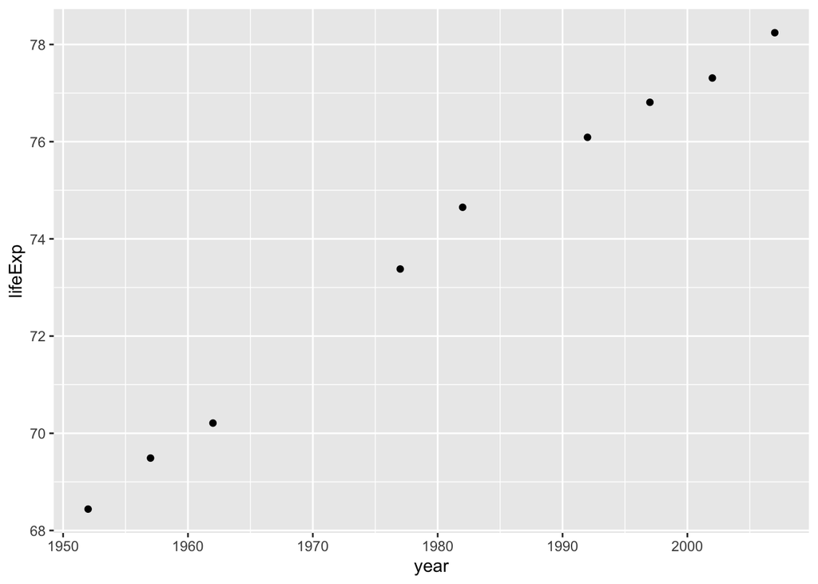

```r
gap_usa <- gap %>%
  filter(country == "United States")

ggplot(data = gap_usa, mapping = aes(x = year, y = lifeExp)) +
  geom_point()
```

**Part 2**

Create a plot of life expectancy verses GDP per capita for Canada. Set the color of the points to be red and connect them with a solid black line.

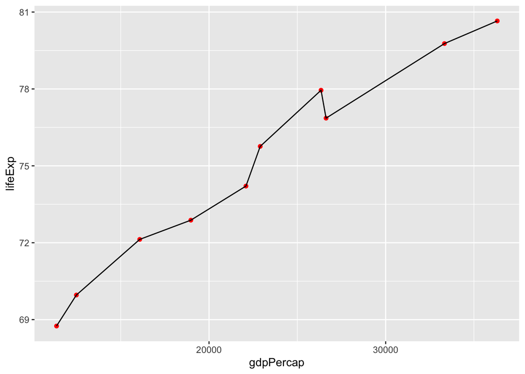

```r
# create plot here
gap_canada <- gap %>%
  filter(country == "Canada")

ggplot(data = gap_canada, mapping = aes(x = gdpPercap, y = lifeExp)) +
  geom_point(color = "red") +
  geom_line()
```

**Part 3**

Create a scatter plot of life expectancy versus GDP per capita based on all countries in Africa in 1992. Set the color to be purple.

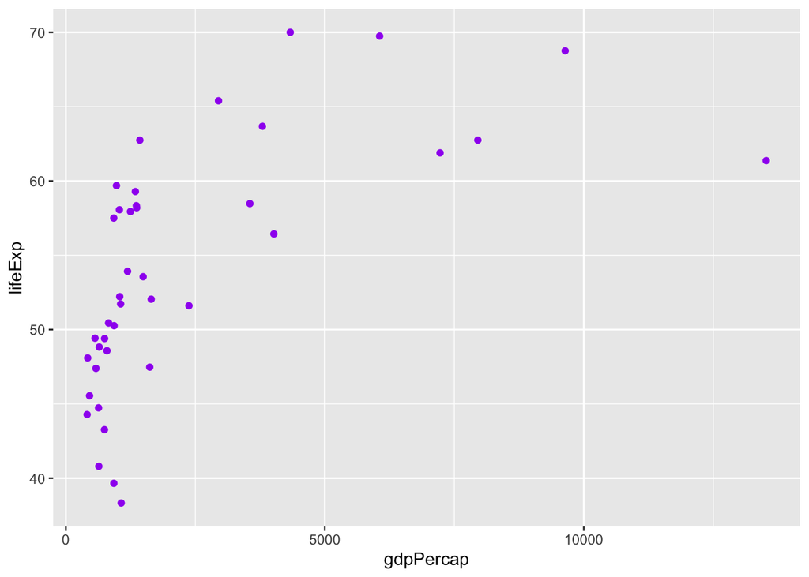

```r
# create plot here
gap_africa <- gap %>%
  filter(continent == "Africa", year == 1992)

ggplot(data = gap_africa, mapping = aes(x = gdpPercap, y = lifeExp)) +
  geom_point(color = "purple")
```

### Exercise 3

**Part 1**

Create a plot of life expectancy versus GDP per capita based on all the countries in Africa and Europe in 1992. Set the point colors to code for the two continents.

*Hints*:

1. Filter `gap` so it only contains observations from Africa or Europe. Do this with `continent %in% c("Africa", "Europe")`. Also, filter so that the observations are only from 1992. Separate multiple conditions with commas.
2. Add another aesthetic to the plot. Instead of just `x` and `y`, include `color = continent` inside function `aes()`. The color of the points will be set for each level of the variable `continent`.

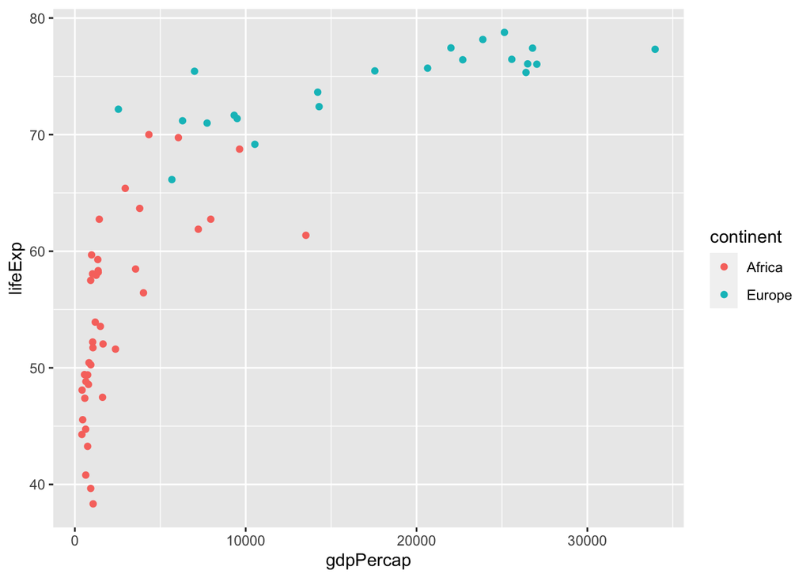

```r
# create plot here
gap_au <- gap %>%
  filter(continent %in% c("Africa", "Europe"), year == 1992)

ggplot(data = gap_au, mapping = aes(x = gdpPercap, y = lifeExp, color = continent)) +
  geom_point()
```

**Part 2**

Create comparison boxplots by continent of GDP per capita for the year 2007. Fill the boxplots with color `darkgreen`.

*Hints*:

1. Filter `gap` so it only contains observations from 2007.
2. Inside `aes()` set `x = continent, y = gdpPercap`.
3. Use `geom_boxplot()` and set the fill to `darkgreen`.

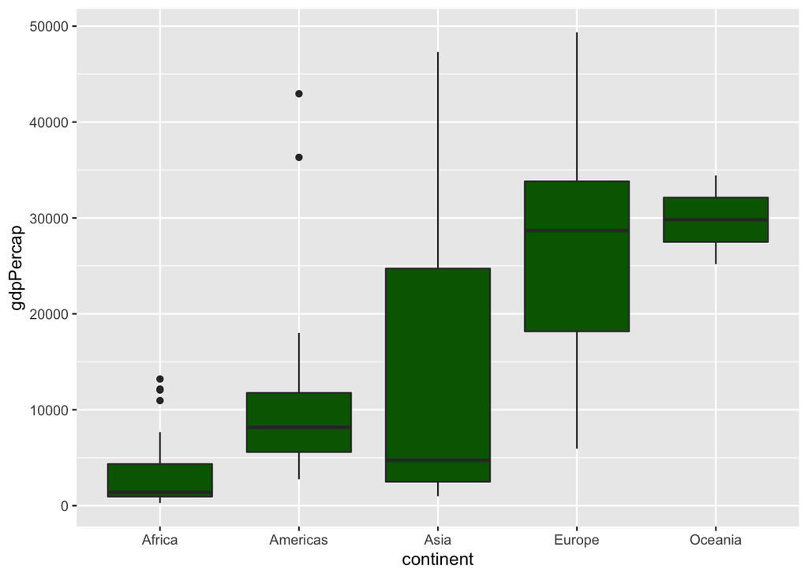

```r
# create plot here
gap_box <- gap %>%
  filter(year == 2007)

ggplot(data = gap_box, mapping = aes(x = continent, y = gdpPercap)) +
  geom_boxplot(fill = "darkgreen")
```

## Reproducibility

```r
gap_upd <- read_csv("https://bit.ly/gap_data_upd")
```

```r
glimpse(gap_upd)
```

```
#> Rows: 1,704
#> Columns: 6
#> $ country   <chr> "Algeria", "Algeria", "Algeria", "Algeria", "Algeria", "Al…
#> $ continent <chr> "Africa", "Africa", "Africa", "Africa", "Africa", "Africa"…
#> $ year      <dbl> 1952, 1957, 1962, 1967, 1972, 1977, 1982, 1987, 1992, 1997…
#> $ lifeExp   <dbl> 43.077, 45.685, 48.303, 51.407, 54.518, 58.014, 61.368, 65…
#> $ pop       <dbl> 9279525, 10270856, 11000948, 12760499, 14760787, 17152804,…
#> $ gdpPercap <dbl> 2449.0082, 3013.9760, 2550.8169, 3246.9918, 4182.6638, 491…
```

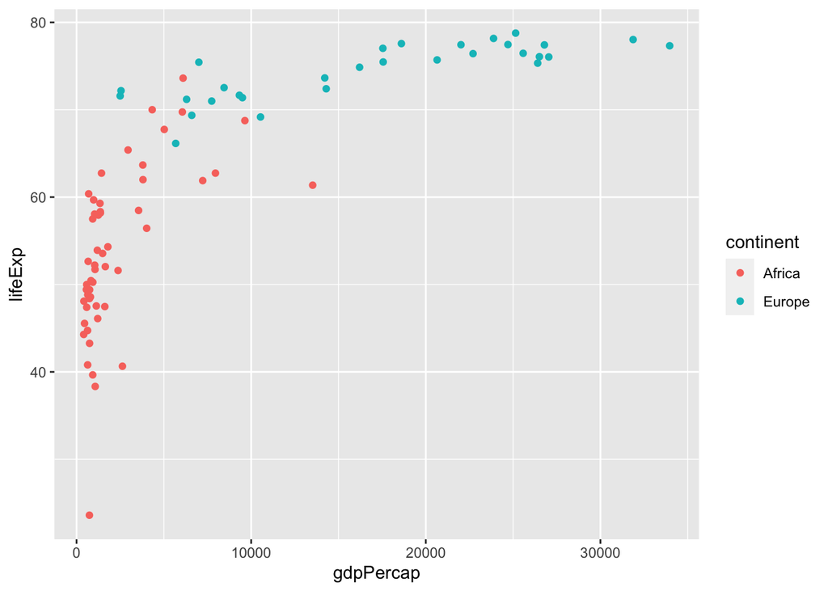

```r
# create plot here
gap_au_upd <- gap_upd %>%
  filter(continent %in% c("Africa", "Europe"), year == 1992)

ggplot(data = gap_au_upd, mapping = aes(x = gdpPercap, y = lifeExp, color = continent)) +
  geom_point()
```

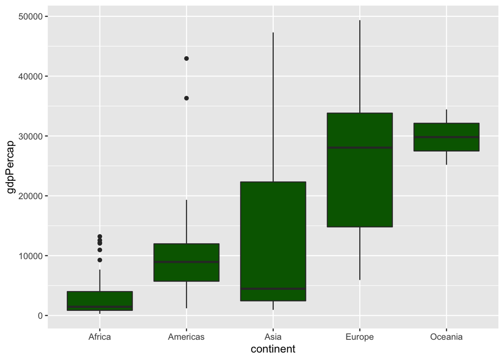

```r
# create plot here
gap_box_upd <- gap_upd %>%
  filter(year == 2007)

ggplot(data = gap_box_upd, mapping = aes(x = continent, y = gdpPercap)) +
  geom_boxplot(fill = "darkgreen")
```